# Analyse der Matoma-HaNS-Daten

## 10.5 Anzahl der Visits nach Datum (Wochen) und Uhrzeit (bin2d)

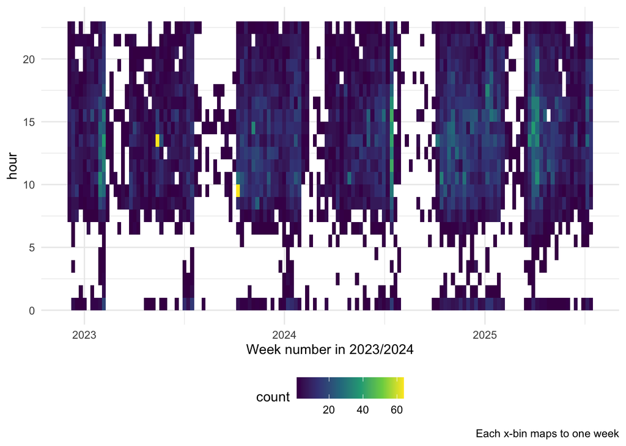

```r
time2 |>
  ggplot(aes(x = date, y = hour)) +
  geom_bin2d(binwidth = c(7, 1)) +  # 1 week, 1 hour
  scale_x_date(date_breaks = "1 week", date_labels = "%W") +
  theme(legend.position = "bottom") +
  scale_fill_viridis_c()  +
  labs(x = "Week number in 2023/2024",
       caption = "Each x-bin maps to one week") +
  scale_x_date(breaks = breaks_pretty())
```

## 10.6 Anzahl der Visits nach Datum (Wochen) und Wochentag (bin2d)

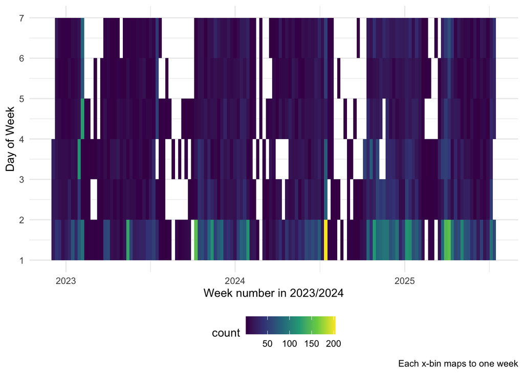

```r
time2 |>
  ggplot(aes(x = date, y = dow)) +
  geom_bin2d(binwidth = c(7, 1)) +  # 1 week, 1 hour
  scale_x_date(date_breaks = "1 week", date_labels = "%W") +
  theme(legend.position = "bottom") +
  scale_fill_viridis_c()  +
  labs(x = "Week number in 2023/2024",
       caption = "Each x-bin maps to one week",
       y = "Day of Week") +
  scale_y_continuous(breaks = 1:7)   +
  scale_x_date(breaks = breaks_pretty())
```

# 11 KI-Gebrauch

## 11.1 Interaktion mit dem LLM

Berechnungsgrundlage: Für diese Analyse wurden alle Events der Kategorie `llm` gefiltert.

### 11.1.1 Art und Anzahl der Interaktionen mit dem LLM

```r
data_slim_filtered_ai <-
data_slim_filtered |>
  filter(type == "eventcategory") |>
  filter(str_detect(value, "llm")) |>
  count(value, sort = TRUE) |>
  mutate(prop = n / sum(n))

data_slim_filtered_ai |>
  gt() |>
  fmt_auto()
```

| value | n | prop |
| --- | --- | --- |
| clear_transcript_text_for_llm_context | 104,108 | 0.988 |
| select_transcript_text_for_llm_context | 468 | 0.004 |
| message_to_llm | 279 | 0.003 |
| message_to_llm_de | 258 | 0.002 |
| llm_response_de | 230 | 0.002 |
| message_to_llm_en | 27 | 2.562 × 10<sup>−4</sup> |
| llm_response_en | 26 | 2.467 × 10<sup>−4</sup> |

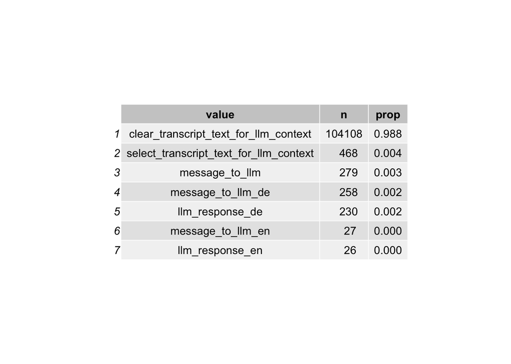

```r
data_slim_filtered_ai |>
  mutate(prop = round(prop, 3)) |>
  ggtexttable()
```

### 11.1.2 Anteil Visitors, die mit dem LLM interagieren

```r
data_slim_filtered_llm_interact <-
data_slim_filtered |>
  mutate(has_llm = str_detect(value, "llm"))  |>
  group_by(idvisit) |>
  summarise(llm_used_during_visit = any(has_llm == TRUE)) |>
  count(llm_used_during_visit) |>
  mutate(prop = round(n /sum(n), 2))

data_slim_filtered_llm_interact|>
  gt()
```

| llm_used_during_visit | n | prop |
| --- | --- | --- |
| FALSE | 10775 | 0.95 |
| TRUE | 608 | 0.05 |

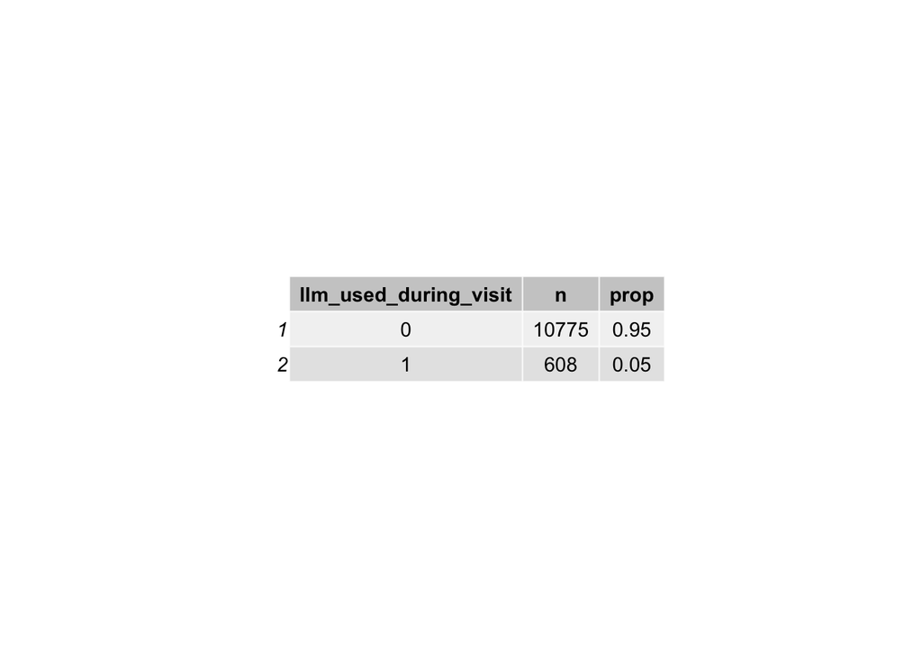

```r
data_slim_filtered_llm_interact |>
  ggtexttable()
```

### 11.1.3 … Im Zeitverlauf

```r
tar_load(idvisit_has_llm)

idvisit_has_llm |>
  head(30)
```

| nr | type | value | idvisit | uses_llm | date_time | dow | hour | year | month | year_month |
| --- | --- | --- | --- | --- | --- | --- | --- | --- | --- | --- |
| 0 | timestamp | 2023-03-23 18:37:56 | 1 | FALSE | 2023-03-23 18:37:56 | 4 | 18 | 2023 | 3 | 2023-3 |
| 1 | timestamp | 2023-03-23 18:37:56 | 1 | FALSE | 2023-03-23 18:37:56 | 4 | 18 | 2023 | 3 | 2023-3 |
| 0 | timestamp | 2023-03-23 17:18:10 | 2 | FALSE | 2023-03-23 17:18:10 | 4 | 17 | 2023 | 3 | 2023-3 |
| 0 | timestamp | 2023-03-23 17:17:36 | 3 | FALSE | 2023-03-23 17:17:36 | 4 | 17 | 2023 | 3 | 2023-3 |
| 0 | timestamp | 2023-03-23 15:15:59 | 4 | FALSE | 2023-03-23 15:15:59 | 4 | 15 | 2023 | 3 | 2023-3 |
| 1 | timestamp | 2023-03-23 15:15:59 | 4 | FALSE | 2023-03-23 15:15:59 | 4 | 15 | 2023 | 3 | 2023-3 |
| 0 | timestamp | 2023-03-23 14:20:12 | 5 | FALSE | 2023-03-23 14:20:12 | 4 | 14 | 2023 | 3 | 2023-3 |
| 0 | timestamp | 2023-03-23 14:29:42 | 6 | FALSE | 2023-03-23 14:29:42 | 4 | 14 | 2023 | 3 | 2023-3 |
| 0 | timestamp | 2023-03-24 17:58:33 | 7 | FALSE | 2023-03-24 17:58:33 | 5 | 17 | 2023 | 3 | 2023-3 |
| 0 | timestamp | 2023-03-24 16:06:55 | 8 | FALSE | 2023-03-24 16:06:55 | 5 | 16 | 2023 | 3 | 2023-3 |

[output cut: 20 more lines]

```r
idvisit_has_llm_timeline <-
idvisit_has_llm |>
  count(year_month, uses_llm) |>
  ungroup() |>
  group_by(year_month) |>
  mutate(prop = round(n/sum(n), 2))

idvisit_has_llm_timeline
```

| year_month | uses_llm | n | prop |
| --- | --- | --- | --- |
| 2022-12 | FALSE | 354 | 1.00 |
| 2023-1 | FALSE | 532 | 1.00 |
| 2023-10 | FALSE | 692 | 1.00 |
| 2023-11 | FALSE | 733 | 0.99 |
| 2023-11 | TRUE | 4 | 0.01 |
| 2023-12 | FALSE | 589 | 1.00 |
| 2023-2 | FALSE | 663 | 1.00 |
| 2023-3 | FALSE | 161 | 1.00 |
| 2023-4 | FALSE | 278 | 1.00 |
| 2023-5 | FALSE | 410 | 1.00 |

[output cut: 40 more lines]

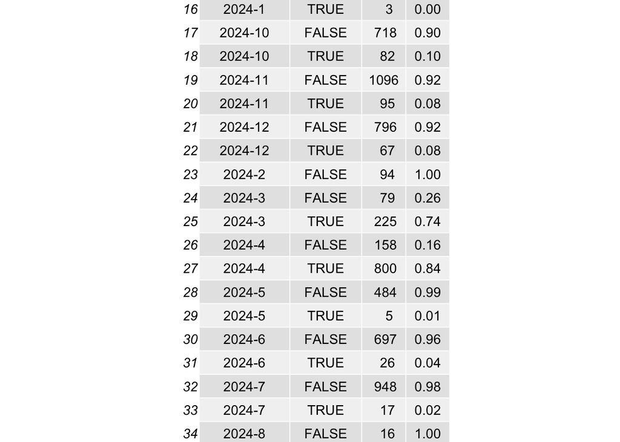

```r
idvisit_has_llm_timeline |>
  ggtexttable()
```

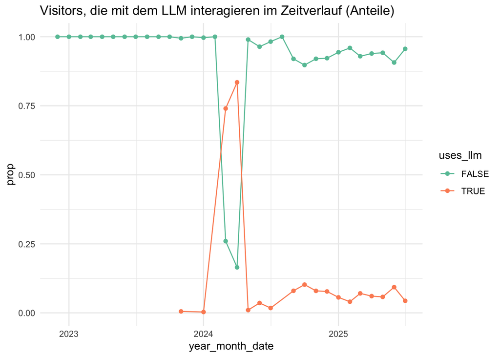

```r
idvisit_has_llm |>
  count(year_month, uses_llm) |>
  ungroup() |>
  mutate(year_month_date = ymd(paste0(year_month,"-01"))) |>
  group_by(year_month_date) |>
  mutate(prop = n/sum(n))  |>
  ggplot(aes(x = year_month_date, y = prop, color = uses_llm, groups = uses_llm)) +
  geom_point() +
  geom_line(aes(group = uses_llm)) +
  labs(title = "Visitors, die mit dem LLM interagieren im Zeitverlauf (Anteile)") +
  scale_x_date(breaks = pretty_breaks())
```

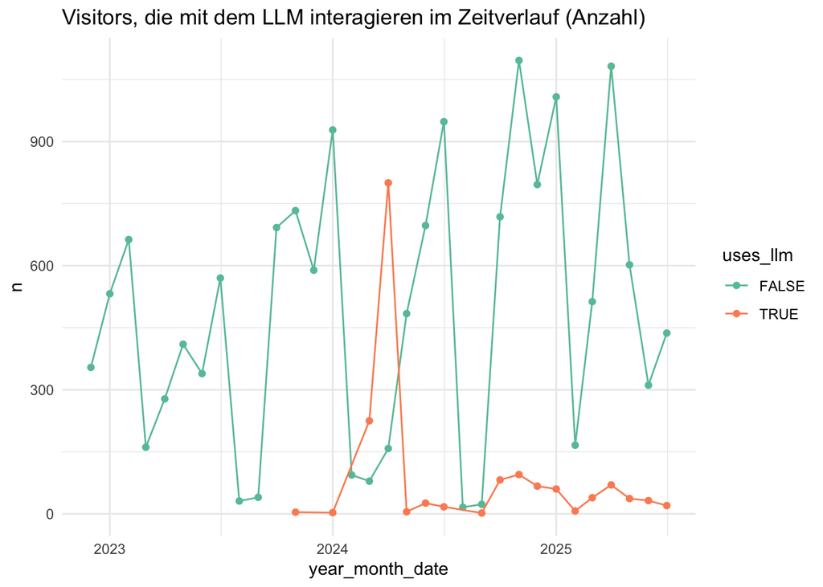

```r
idvisit_has_llm |>
  count(year_month, uses_llm) |>
  ungroup()  |>
  mutate(year_month_date = ymd(paste0(year_month,"-01"))) |>
  group_by(year_month) |>
  ggplot(aes(x = year_month_date, y = n, color = uses_llm, groups = uses_llm)) +
  geom_point() +
  geom_line(aes(group = uses_llm)) +
  labs(title = "Visitors, die mit dem LLM interagieren im Zeitverlauf (Anzahl)") +
  scale_x_date(breaks = pretty_breaks())
```

## 11.2 Anzahl der Interaktionen bei den Usern, die mit dem LLM interagieren

```r
d_n_interactions_w_llm <-
data_slim_filtered |>
  filter(type == "eventcategory") |>
  filter(str_detect(value, "llm")) |>
  group_by(idvisit) |>
  summarise(n_interactions_w_llm = n())
```

```
d_n_interactions_w_llm |>
  select(n_interactions_w_llm) |>
  describe_distribution() |>
  print_md()
```

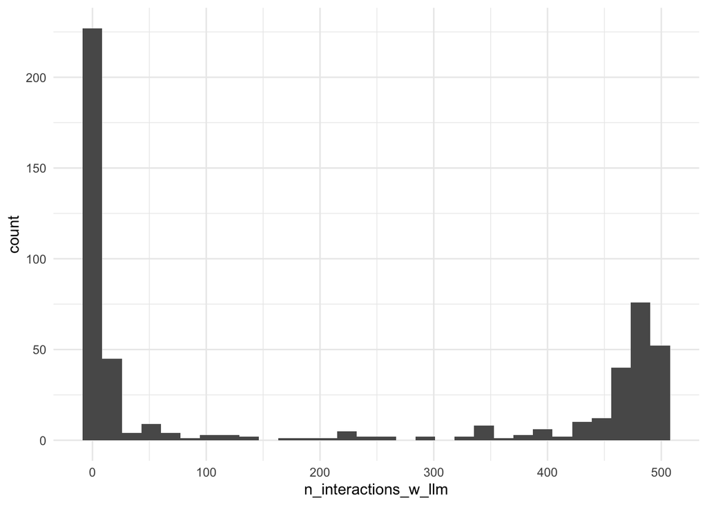

```r
d_n_interactions_w_llm |>
  ggplot(aes(x = n_interactions_w_llm)) +
  geom_histogram()
```

## 11.3 Klick auf ein Wort im Transkript

Ausgewertet wird im Folgenden die Variable “click_transcript_word”.

### 11.3.1 Insgesamt

```r
data_slim_filtered |>
  filter(type == "subtitle") |>
  # rm empty rows:
  filter(!is.na(value) & value != "") |>
  count(click_transcript_word = str_detect(value, "click_transcript_word")) |>
  mutate(prop = round(n/sum(n), 2)) |>
  tt()
```

| click_transcript_word | n | prop |
| --- | --- | --- |
| FALSE | 910840 | 0.99 |
| TRUE | 7882 | 0.01 |

### 11.3.2 Im Zeitverlauf

```r
click_transcript_word_per_month <-
data_slim_filtered |>
  # rm all groups WITHOUT "click_transcript_word":
  group_by(idvisit) |>
  filter(!any(value = str_detect(value, "click_transcript_word"))) |>
  ungroup() |>
  mutate(date_visit = ymd_hms(value)) |>
  mutate(month_visit = floor_date(date_visit, unit = "month")) |>
  drop_na(date_visit) |>
  group_by(idvisit) |>
  slice(1) |>
  ungroup() |>
  count(month_visit)

click_transcript_word_per_month
```

| month_visit | n |
| --- | --- |
| 2022-12-01 | 293 |
| 2023-01-01 | 369 |
| 2023-02-01 | 486 |
| 2023-03-01 | 141 |
| 2023-04-01 | 232 |
| 2023-05-01 | 337 |
| 2023-06-01 | 256 |
| 2023-07-01 | 381 |
| 2023-08-01 | 26 |
| 2023-09-01 | 37 |

[output cut: 18 more lines]

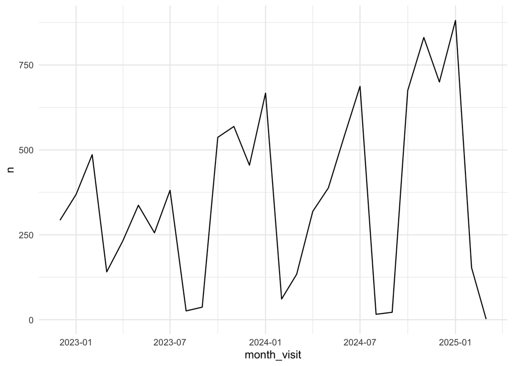

```r
click_transcript_word_per_month |>
  ggplot(aes(x = month_visit, y = n)) +
  geom_line()
```

## 11.4 KI-Aktionen

### 11.4.1 Insgesamt (ganzer Zeitraum)

```r
tar_load(data_long)
```

```r
data_long |>
  head(300)
```

| idvisit | variable | value |
| --- | --- | --- |
| 1 | actiondetails_0_type | action |
| 2 | actiondetails_0_type | action |
| 3 | actiondetails_0_type | action |
| 4 | actiondetails_0_type | event |
| 5 | actiondetails_0_type | action |
| 6 | actiondetails_0_type | action |
| 7 | actiondetails_0_type | event |
| 8 | actiondetails_0_type | event |
| 9 | actiondetails_0_type | event |
| 10 | actiondetails_0_type | action |

[output cut: 290 more lines]

#### 11.4.1.1 Im Detail

```r
regex_pattern <-  "Category: \"(.*?)(?=', Action)"

# Explaining this regex_pattern:
# Find the literal string
# 1. `Category: ` (surrounded by quotation marks)
# 2. Capture any characters (.*?) that follow, non-greedily, until...
# 3. ...it encounters the literal sequence,  ` Action`) immediately after the captured string.

ai_actions_count <-
  data_long |>
 # slice(1:1000) |>
  filter(str_detect(value, "transcript")) |>
  mutate(category = str_extract(value, regex_pattern)) |>
  select(category) |>
  mutate(category = str_replace_all(category, "[\"']", "")) |>
  count(category, sort = TRUE)

ai_actions_count |>
  tt()
```

| category | n |
| --- | --- |
| NA | 217862 |
| Category: clear_transcript_text_for_llm_context | 104111 |
| Category: click_transcript_word | 8439 |
| Category: select_transcript_text_for_llm_context | 576 |
| Category: click_button | 43 |
| Category: llm_response_de | 3 |
| Category: llm_response_en | 3 |

### 11.4.2 KI-Klicks pro Monat

Im Objekt wird gezählt, wie oft der String `"click_transcript_word"` in den Daten (Langformat) gefunden wird, s. Target `ai_transcript_clicks_per_month` in der Targets-Pipeline.

```r
tar_load(ai_transcript_clicks_per_month)

ai_transcript_clicks_per_month |>
  head(30)
```

| nr | type | value | idvisit | clicks_transcript_any | date_time | dow | hour | year | month | year_month |
| --- | --- | --- | --- | --- | --- | --- | --- | --- | --- | --- |
| 0 | timestamp | 2023-03-23 18:37:56 | 1 | TRUE | 2023-03-23 18:37:56 | 4 | 18 | 2023 | 3 | 2023-3 |
| 1 | timestamp | 2023-03-23 18:37:56 | 1 | TRUE | 2023-03-23 18:37:56 | 4 | 18 | 2023 | 3 | 2023-3 |
| 0 | timestamp | 2023-03-23 17:18:10 | 2 | FALSE | 2023-03-23 17:18:10 | 4 | 17 | 2023 | 3 | 2023-3 |
| 0 | timestamp | 2023-03-23 17:17:36 | 3 | FALSE | 2023-03-23 17:17:36 | 4 | 17 | 2023 | 3 | 2023-3 |
| 0 | timestamp | 2023-03-23 15:15:59 | 4 | FALSE | 2023-03-23 15:15:59 | 4 | 15 | 2023 | 3 | 2023-3 |
| 1 | timestamp | 2023-03-23 15:15:59 | 4 | FALSE | 2023-03-23 15:15:59 | 4 | 15 | 2023 | 3 | 2023-3 |
| 0 | timestamp | 2023-03-23 14:20:12 | 5 | FALSE | 2023-03-23 14:20:12 | 4 | 14 | 2023 | 3 | 2023-3 |
| 0 | timestamp | 2023-03-23 14:29:42 | 6 | FALSE | 2023-03-23 14:29:42 | 4 | 14 | 2023 | 3 | 2023-3 |
| 0 | timestamp | 2023-03-24 17:58:33 | 7 | FALSE | 2023-03-24 17:58:33 | 5 | 17 | 2023 | 3 | 2023-3 |
| 0 | timestamp | 2023-03-24 16:06:55 | 8 | FALSE | 2023-03-24 16:06:55 | 5 | 16 | 2023 | 3 | 2023-3 |

[output cut: 20 more lines]

```r
ai_transcript_clicks_per_month_count <-
ai_transcript_clicks_per_month |>
  count(year_month, clicks_transcript_any) |>
  ungroup() |>
  group_by(year_month) |>
  mutate(prop = round(n/sum(n), 2))

ai_transcript_clicks_per_month_count
```

| year_month | clicks_transcript_any | n | prop |
| --- | --- | --- | --- |
| 2022-12 | FALSE | 315 | 0.89 |
| 2022-12 | TRUE | 39 | 0.11 |
| 2023-1 | FALSE | 435 | 0.82 |
| 2023-1 | TRUE | 97 | 0.18 |
| 2023-10 | FALSE | 613 | 0.89 |
| 2023-10 | TRUE | 79 | 0.11 |
| 2023-11 | FALSE | 645 | 0.88 |
| 2023-11 | TRUE | 92 | 0.12 |
| 2023-12 | FALSE | 510 | 0.87 |
| 2023-12 | TRUE | 79 | 0.13 |

[output cut: 52 more lines]

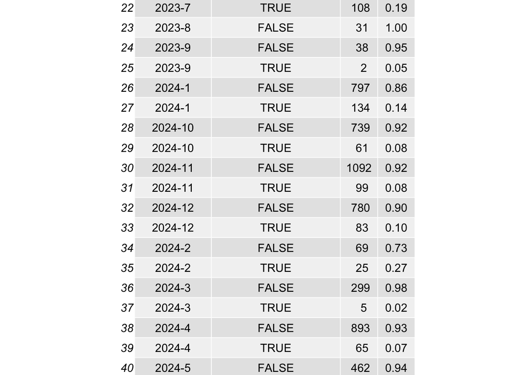

```r
ai_transcript_clicks_per_month_count |>
  ggtexttable()
```

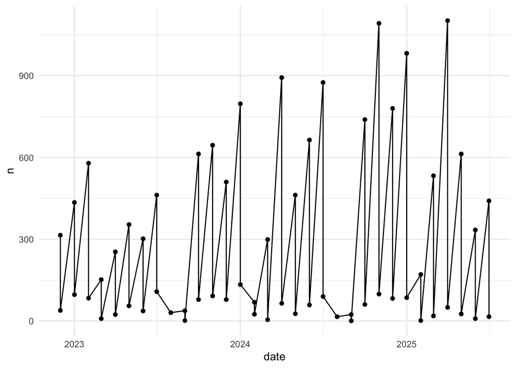

```r
ai_transcript_clicks_per_month_count |>
  mutate(date = ymd(paste0(year_month,"-01"))) |>
  ggplot(aes(x = date, y = n)) +
  geom_line(group = 1) +
  geom_point() +
  theme_minimal()
```

## 11.5 Output des LLMs: `llm_response`

```r
tar_load(llm_response_text)
```

### 11.5.1 Deutsch vs. Englisch

```r
llm_response_text |>
  count(lang) |>
  mutate(prob = n/sum(n))
```

| lang | n | prob |
| --- | --- | --- |
| de | 370 | 0.93198992 |
| en | 27 | 0.06801008 |

### 11.5.2 Anzahl der Tokens

```r
llm_response_text |>
  describe_distribution(select = "tokens_n") |>
  print_md()
```

| Variable | Mean | SD | IQR | Range | Skewness | Kurtosis | n | n_Missing |
| --- | --- | --- | --- | --- | --- | --- | --- | --- |
| tokens_n | 184.14 | 104.40 | 155.50 | (11.00, 656.00) | 0.45 | 0.31 | 397 | 0 |

### 11.5.3 Anzahl vorab existierender Fragen

#### 11.5.3.1 Anzahl `verify_option_wrong`

```r
verify_option_summary <-
data_slim_filtered |>
  group_by(idvisit) |>
  filter(value == "verify_option_wrong" | value == "verify_option_correct") |>
  summarise(verify_option = n())
```

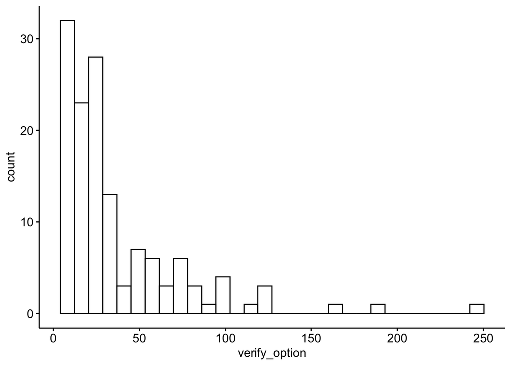

```r
verify_option_summary |>
  gghistogram(x = "verify_option")
```

```r
verify_option_summary |>
  describe_distribution(verify_option) |>
  print_md()
```

| Variable | Mean | SD | IQR | Range | Skewness | Kurtosis | n | n_Missing |
| --- | --- | --- | --- | --- | --- | --- | --- | --- |
| verify_option | 36.49 | 38.11 | 35.75 | (7.00, 245.00) | 2.48 | 8.28 | 136 | 0 |

#### 11.5.3.2 Anzahl `generate_questionaire`

```r
generate_questionaire_summary <-
data_slim_filtered |>
  group_by(idvisit) |>
  filter(value == "generate_questionaire") |>
  summarise(generate_questionaire = n())
```

```r
generate_questionaire_summary |>
  describe_distribution(generate_questionaire) |>
  print_md()
```

| Variable | Mean | SD | IQR | Range | Skewness | Kurtosis | n | n_Missing |
| --- | --- | --- | --- | --- | --- | --- | --- | --- |
| generate_questionaire | 3.08 | 6.16 | 1 | (1.00, 66.00) | 5.84 | 44.20 | 329 | 0 |

#### 11.5.3.3 Anzahl vorab existierender Fragen

```r
prior_existing_questions_summary <-
generate_questionaire_summary |>
  full_join(verify_option_summary) |>
  mutate(prior_existing_questions_n = verify_option - generate_questionaire)
```

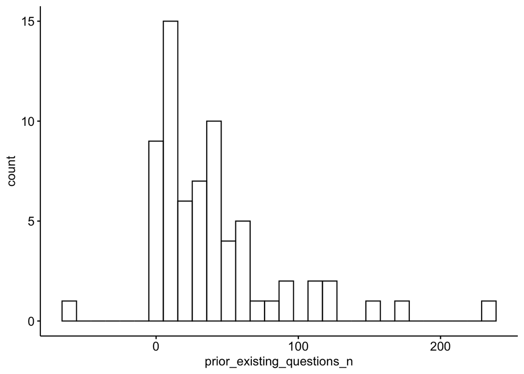

```r
prior_existing_questions_summary |>
 # drop_na() |>
  gghistogram(x = "prior_existing_questions_n")
```

```r
prior_existing_questions_summary |>
  describe_distribution(prior_existing_questions_n) |>
  print_md()
```

| Variable | Mean | SD | IQR | Range | Skewness | Kurtosis | n | n_Missing |
| --- | --- | --- | --- | --- | --- | --- | --- | --- |
| prior_existing_questions_n | 40.24 | 46.31 | 42.25 | (-59.00, 236.00) | 1.82 | 4.87 | 68 | 329 |

# 12 Videozeit

Wie viel Zeit verbringen die Nutzer mit dem Betrachten von Videos (“Glotzdauer”)?

## 12.1 Glotzdauer allgemein

Achtung: Die Videozeit ist schwierig auszuwerten. Die Nutzer beenden keine Videos, in dem sie auf “Pause” drücken, sondern indem sie andere Aktionen durchführen. Dies ist aber analytisch schwer abzubilden.

```r
tar_load(data_separated_distinct_slice)
```

Vgl. die Definition des Targets `glotzdauer` in der [Pipeline](https://github.com/sebastiansauer/hans/blob/main/_targets.R#L269).

Kurz gesagt wird die Zeit-Differenz zwischen zwei aufeinander folgenden “Play” und “Pause” Aktionen berechnet.

Allerdings hat dieses Vorgehen Schwierigkeiten: Nicht immer folgt auf einem “Play” ein “Pause”. Es ist schwer auszuwerten, wann die Betrachtung eines Videos endet. Daher ist diese Analyse nur vorsichtig zu interpretieren.

Die Definition [der Funktion glotzdauer.R](https://github.com/sebastiansauer/hans/blob/main/funs/glotzdauer.R) ist online dokumentiert.

```r
data_separated_distinct_slice |>
  head(30)
```

| idvisit | first_play | last_pause | date | time_diff |
| --- | --- | --- | --- | --- |
| 1 | 2023-03-23 18:44:33 | 2023-03-23 19:02:45 | 2023-03-23 | 1092 secs |
| 3 | 2023-03-23 17:18:39 | NA | 2023-03-23 | NA secs |
| 4 | 2023-03-23 15:25:29 | 2023-03-23 15:49:34 | 2023-03-23 | 1445 secs |
| 7 | 2023-03-24 17:58:33 | 2023-03-24 18:08:21 | 2023-03-24 | 588 secs |
| 8 | 2023-03-24 16:06:59 | 2023-03-24 16:07:32 | 2023-03-24 | 33 secs |
| 9 | 2023-03-24 16:21:10 | 2023-03-24 16:26:44 | 2023-03-24 | 334 secs |
| 10 | 2023-03-24 16:06:36 | NA | 2023-03-24 | NA secs |
| 11 | 2023-03-24 14:37:12 | 2023-03-24 14:37:20 | 2023-03-24 | 8 secs |
| 12 | 2023-03-24 13:38:22 | NA | 2023-03-24 | NA secs |
| 13 | 2023-03-24 13:26:00 | 2023-03-24 13:34:27 | 2023-03-24 | 507 secs |

[output cut: 20 more lines]

Für die folgende Darstellung wurden die *absoluten* Zeitwerte verwendet, d.h. ohne Vorzeichen.

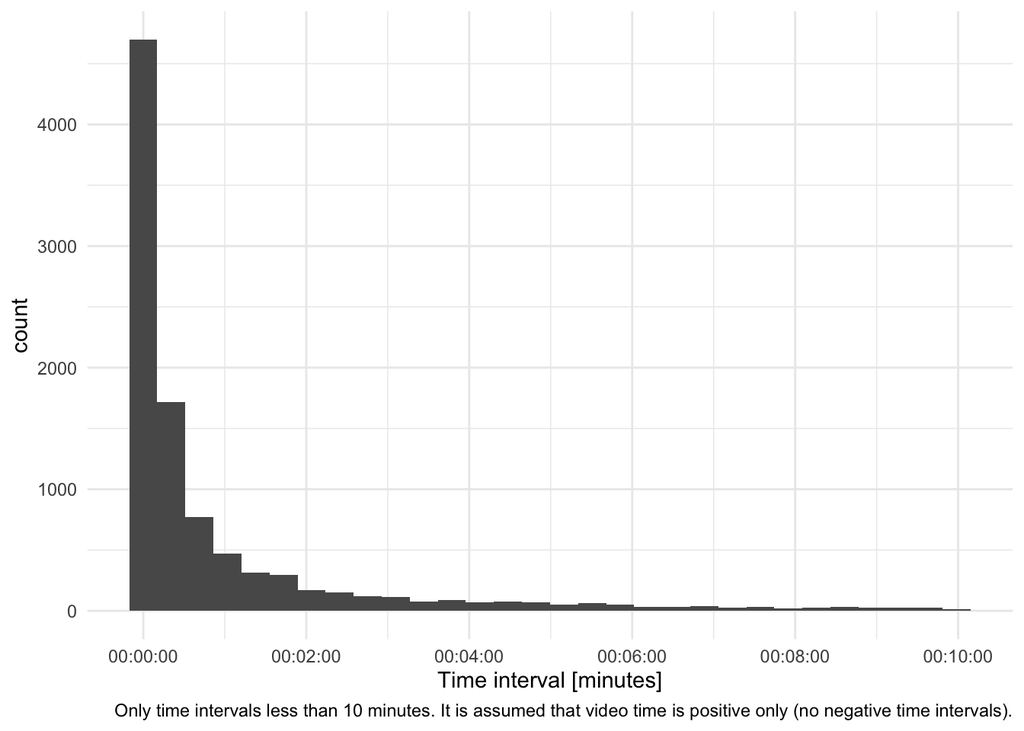

```r
data_separated_distinct_slice |>
  # we will assume that negative glotzdauer is the as positive glotzdauer:
  mutate(time_diff = abs(time_diff)) |>
  # without glotzdauer smaller than 10 minutes:
  filter(time_diff < 60*10) |>
  ggplot(aes(x = time_diff)) +
  geom_histogram() +
  scale_x_time() +
  labs(x = "Time interval [minutes]",
       caption = "Only time intervals less than 10 minutes. It is assumed that video time is positive only (no negative time intervals).") +
  theme_minimal()
```

```r
glotzdauer_prepped <-
data_separated_distinct_slice |>
  # we will assume that negative glotzdauer is the as positive glotzdauer:
  mutate(time_diff_abs_sec = abs(as.numeric(time_diff, units = "secs"))) |>
  # without glotzdauer smaller than 10 minutes:
  filter(time_diff_abs_sec < 60*10) |>
  mutate(time_diff_abs_min = time_diff_abs_sec / 60)

glotzdauer_tbl <-
  glotzdauer_prepped |>
  select(time_diff_abs_sec, time_diff_abs_min) |>
  describe_distribution()

glotzdauer_tbl
```

| Variable | Mean | SD | IQR | Min | Max | Skewness | Kurtosis | n | n_Missing |
| --- | --- | --- | --- | --- | --- | --- | --- | --- | --- |
| time_diff_abs_sec | 57.0715316 | 105.820477 | 52.0000000 | 0 | 599.000000 | 2.805253 | 8.078527 | 9702 | 0 |
| time_diff_abs_min | 0.9511922 | 1.763675 | 0.8666667 | 0 | 9.983333 | 2.805253 | 8.078527 | 9702 | 0 |

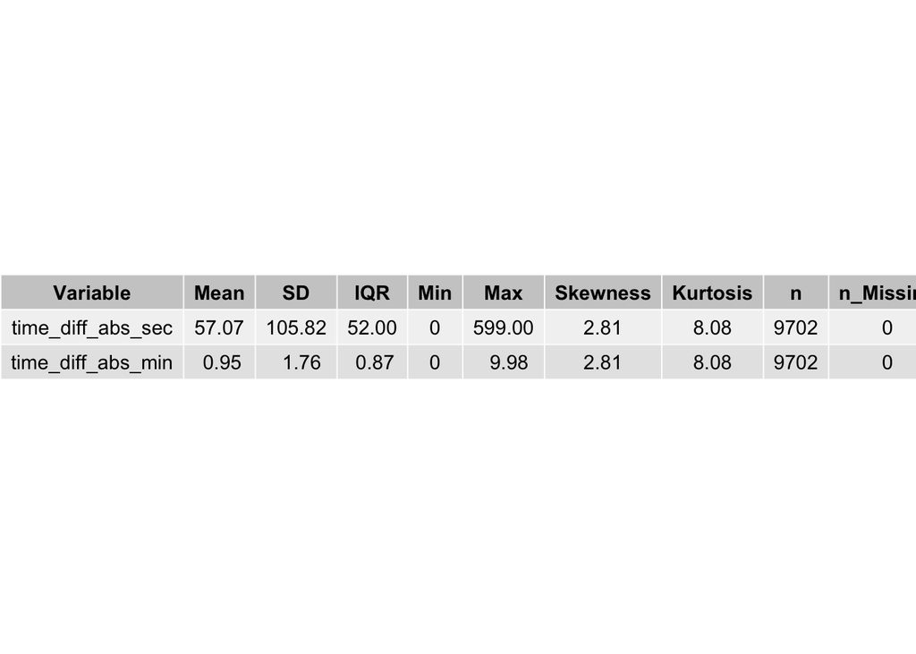

```r
glotzdauer_tbl |>
  mutate(across(where(is.numeric), ~ round(., 2))) |>
  ggpubr::ggtexttable()
```

## 12.2 Glotzdauer im Zeitverlauf

```r
glotzdauer_prepped_tbl <-
glotzdauer_prepped |>
  mutate(first_of_month = floor_date(date, unit = "month")) |>
  group_by(first_of_month) |>
  summarise(time_diff_mean = mean(time_diff, na.rm = TRUE))


glotzdauer_prepped_tbl
```

| first_of_month | time_diff_mean |
| --- | --- |
| 2022-12-01 | 49.444898 secs |
| 2023-01-01 | 65.310249 secs |
| 2023-02-01 | 46.114719 secs |
| 2023-03-01 | 49.478873 secs |
| 2023-04-01 | 51.186667 secs |
| 2023-05-01 | 47.210169 secs |
| 2023-06-01 | 47.288991 secs |
| 2023-07-01 | 31.129338 secs |
| 2023-08-01 | 126.222222 secs |
| 2023-09-01 | 14.500000 secs |

[output cut: 22 more lines]

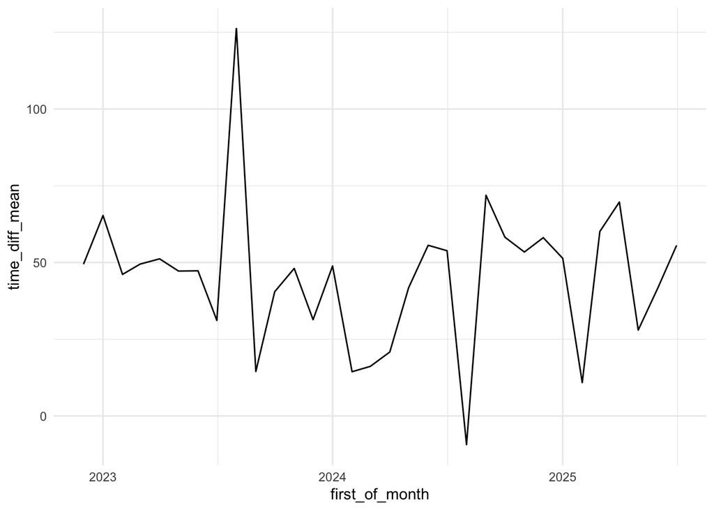

```r
glotzdauer_prepped_tbl |>
  ggplot(aes(x = first_of_month, y = time_diff_mean)) +
  geom_line() +
  theme_minimal()
```